# Quiz 4 Assessment

Justice Chawanda

2025-06-28

#0. Loading the Data and Packages The chunk of code below begins with loading the necessary libraries for Data Manipulation and Data Visualization. Just to mention there is`ggplot2` which is a popular library for visualization and far more important it contains a built-in data set which is the one being used. Apart from that there is `dplyr` which is used for data analyses. again there is `tidyr` which allows tidying up data, making sure its in neat format. Finally, `patchwork` is uploaded used for combining plots into one cohesive layout for easy comparison.

```r
# Load necessary libraries

library(ggplot2)
library(dplyr)
library(tidyr)
library(patchwork)

# Load diamonds data set
data("diamonds")
print(diamonds)
```

```
## # A tibble: 53,940 × 10
##    carat cut       color clarity depth table price     x     y     z
##    <dbl> <ord>     <ord> <ord>   <dbl> <dbl> <int> <dbl> <dbl> <dbl>
##  1  0.23 Ideal     E     SI2      61.5    55   326  3.95  3.98  2.43
##  2  0.21 Premium   E     SI1      59.8    61   326  3.89  3.84  2.31
##  3  0.23 Good      E     VS1      56.9    65   327  4.05  4.07  2.31
##  4  0.29 Premium   I     VS2      62.4    58   334  4.2   4.23  2.63
##  5  0.31 Good      J     SI2      63.3    58   335  4.34  4.35  2.75
##  6  0.24 Very Good J     VVS2     62.8    57   336  3.94  3.96  2.48
##  7  0.24 Very Good I     VVS1     62.3    57   336  3.95  3.98  2.47
##  8  0.26 Very Good H     SI1      61.9    55   337  4.07  4.11  2.53
##  9  0.22 Fair      E     VS2      65.1    61   337  3.87  3.78  2.49
## 10  0.23 Very Good H     VS1      59.4    61   338  4     4.05  2.39
## # ℹ 53,930 more rows
```

#1. Summarize Distribution of Key Variables by Cut The code groups the diamonds data set by the cut of each diamond and then calculates the following averages for each cut category:

avg_price: The average price of diamonds in US dollars ($326–$18,823) in each cut category. avg_carat: The average weight (in carats) of diamonds (0.2–5.01) in each cut category. avg_depth: The average depth percentage, measures height of diamond from top to bottom relative to diameter. avg_table: The average table percentage, which is the width of the diamond’s top relative to its width.

```r
diamonds %>%
  group_by(cut) %>%
  summarize(
    avg_price = mean(price),
    avg_carat = mean(carat),
    avg_depth = mean(depth),
    avg_table = mean(table),
    .groups = "drop"
  )
```

```
## # A tibble: 5 × 5
##   cut       avg_price avg_carat avg_depth avg_table
##   <ord>         <dbl>     <dbl>     <dbl>     <dbl>
## 1 Fair          4359.     1.05       64.0      59.1
## 2 Good          3929.     0.849      62.4      58.7
## 3 Very Good     3982.     0.806      61.8      58.0
## 4 Premium       4584.     0.892      61.3      58.7
## 5 Ideal         3458.     0.703      61.7      56.0
```

Interpretation of Each cut Category:

Fair

avg_price: $4,358.76, avg_carat: 1.0461 carats, avg_depth: 64.04%, avg_table: 59.05% The Fair cut diamonds have the highest average carat weight among all categories but are generally less expensive than Premium cuts. Their depth and table percentages are relatively high, which can affect brilliance.

Good

avg_price: $3,928.86, avg_carat: 0.8492 carats, avg_depth: 62.37%, avg_table: 58.69% Diamonds with a Good cut are slightly lighter on average than Fair cut diamonds and have lower prices. They are also somewhat shallower in depth and table percentages.

Very Good

avg_price: $3,981.76, avg_carat: 0.8064 carats, avg_depth: 61.82%, avg_table: 57.96% Very Good cut diamonds are typically smaller in carat weight and price than Fair cut diamonds but have a more balanced depth and table ratio, which likely improves their appearance.

Premium

avg_price: $4,584.26, avg_carat: 0.8920 carats, avg_depth: 61.26%, avg_table: 58.75% Premium cut diamonds command higher prices, close to those of Fair cuts but with a lower carat weight. Their depth is slightly lower than Very Good cuts, and they have a balanced table percentage, contributing to a desirable sparkle.

Ideal

avg_price: $3,457.54, avg_carat: 0.7028 carats, avg_depth: 61.71%, avg_table: 55.95% Ideal cut diamonds have the lowest average carat weight and price among all categories but are cut to maximize light reflection. The lower table and balanced depth percentage enhance their brilliance and appearance.

#2. Create Focused Subset of Data

The code first defines the Quantile of 25th percentile of price and 9th percentile of carat. What follows is filtering the data set to include only rows where price is above 25th percentile and carat is below 90th percentile resulting in a subset that focuses on mid-range prices and excludes the heaviest diamonds.

```r
price_25th <- quantile(diamonds$price, 0.25)
carat_90th <- quantile(diamonds$carat, 0.90)

diamonds_focused <- diamonds %>%
  filter(price > price_25th, carat < carat_90th)
diamonds_focused
```

```
## # A tibble: 35,008 × 10
##    carat cut       color clarity depth table price     x     y     z
##    <dbl> <ord>     <ord> <ord>   <dbl> <dbl> <int> <dbl> <dbl> <dbl>
##  1  0.7  Ideal     E     SI1      62.5    57  2757  5.7   5.72  3.57
##  2  0.86 Fair      E     SI2      55.1    69  2757  6.45  6.33  3.52
##  3  0.7  Ideal     G     VS2      61.6    56  2757  5.7   5.67  3.5
##  4  0.71 Very Good E     VS2      62.4    57  2759  5.68  5.73  3.56
##  5  0.78 Very Good G     SI2      63.8    56  2759  5.81  5.85  3.72
##  6  0.7  Good      E     VS2      57.5    58  2759  5.85  5.9   3.38
##  7  0.7  Good      F     VS1      59.4    62  2759  5.71  5.76  3.4
##  8  0.96 Fair      F     SI2      66.3    62  2759  6.27  5.95  4.07
##  9  0.73 Very Good E     SI1      61.6    59  2760  5.77  5.78  3.56
## 10  0.8  Premium   H     SI1      61.5    58  2760  5.97  5.93  3.66
## # ℹ 34,998 more rows
```

#3. Median Price and Carat by Color and Clarity

The code groups diamonds by their color and clarity, then calculates the median price and median carat weight for each combination. The output table shows how these median values vary across different color and clarity levels, helping to compare typical price and size within each group.

```r
diamonds_focused %>%
  group_by(color, clarity) %>%
  summarize(
    median_price = median(price),
    median_carat = median(carat),
    .groups = "drop"
  )
```

```
## # A tibble: 56 × 4
##    color clarity median_price median_carat
##    <ord> <ord>          <dbl>        <dbl>
##  1 D     I1             3780          1.12
##  2 D     SI2            3886          0.93
##  3 D     SI1            2972          0.73
##  4 D     VS2            1942.         0.54
##  5 D     VS1            2252.         0.57
##  6 D     VVS2           2366          0.51
##  7 D     VVS1           1754          0.43
##  8 D     IF             4716          0.61
##  9 E     I1             3296.         1.02
## 10 E     SI2            3726          0.91
## # ℹ 46 more rows
```

#4. Patterns in Median Price across Color and Clarity

Color Impact at Similar Clarity: Diamonds with slightly lower color grades (F, G) are generally less expensive than D or E color diamonds, even at the same clarity level, indicating that color significantly influences price.

Middle-Range Combinations: Diamonds with mid-range color (G, H) and clarity (VS1, VS2) have median prices that fall between high and low extremes, appealing to buyers seeking quality without the highest price.

#6.Scatter Plot of Carat vs. Price This R code uses the ggplot2 package to create a scatter plot that visualizes the relationship between the carat weight of diamonds and their price, while also distinguishing different cuts of diamonds and varying table sizes.

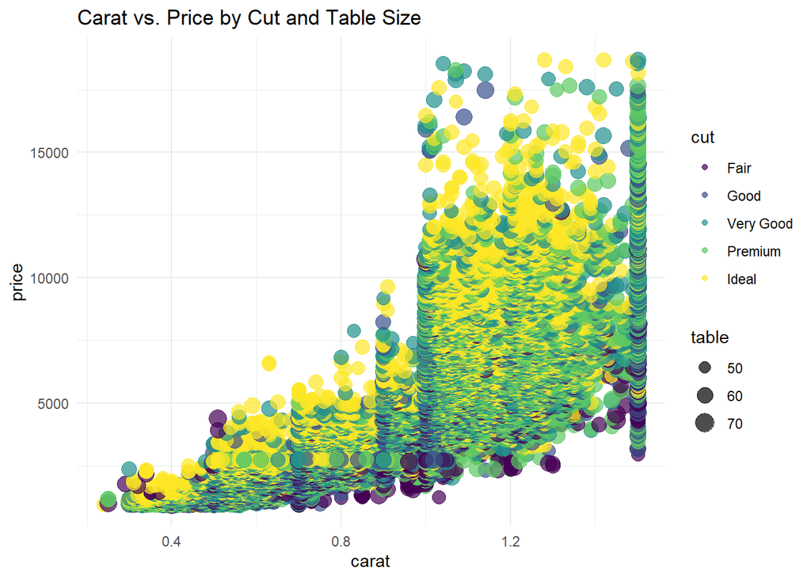

```r
ggplot(diamonds_focused, aes(x = carat, y = price, color = cut, size = table)) +
  geom_point(alpha = 0.7) +
  scale_color_viridis_d() +
  labs(title = "Carat vs. Price by Cut and Table Size") +
  theme_minimal()
```

#7.Describe Visible Clusters or Patterns

Carat and Price: Price generally increases with carat weight, with smaller diamonds clustered at lower prices, while higher-carat diamonds vary widely in price.

Clusters: There is a dense cluster of small, affordable diamonds at low prices, while higher carat diamonds are less frequent and show a wider price range.

In essence, carat and cut quality are key factors in diamond pricing, with table size having a secondary influence.

#8. Boxplots of Price across Cut Levels by Color

The code creates a grid of box plots using ggplot2 in R to show how diamond prices vary across different cut levels (Fair, Good, Very Good, Premium, Ideal) and color grades (D to J). Each panel represents a specific cut level, and within each panel, box plots display price distributions for each color. The box plots are colored by cut, and a minimal theme is applied to keep the plot clean.

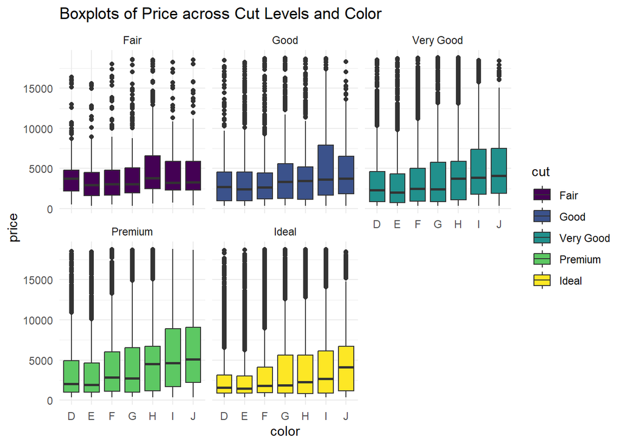

```r
ggplot(diamonds, aes(x = color, y = price, fill = cut)) +
  geom_boxplot() +
  facet_wrap(~cut) +
  theme_minimal() +
  labs(title = "Boxplots of Price across Cut Levels and Color")
```

Unusual Patterns: In Ideal and Premium cuts, diamonds with colors F to I show a bigger price range, meaning buyers will still pay high prices for a well-cut diamond even if it has a little color. In lower-quality cuts like Fair and Good, prices don’t change much between color grades, as color is less important when the cut is not as good.

Outliers: Some very high-priced diamonds in Ideal and Premium cuts, especially in colors like G and H, are likely large diamonds. Their size and good cut make them valuable, even if they have a small amount of color.

#11. Create Value Index Variable

This code creates a new column called value_index in the diamonds data set, calculated by dividing each diamond’s price by its carat weight. The value_index represents the price per carat, allowing for an easier comparison of value across diamonds of different sizes.

```r
diamonds <- diamonds %>%
  mutate(value_index = price / carat)
```

#12. Mean Value Index by Clarity and Cut

The code computes the mean value index of diamonds based on their clarity and cut. It groups the diamonds data set by these two factors, calculates the mean value index for each group, and then visualizes the results as a heatmap using ggplot2. The heatmap displays clarity on the x-axis, cut on the y-axis, and colors indicating the mean value index, helping to identify trends in the data.

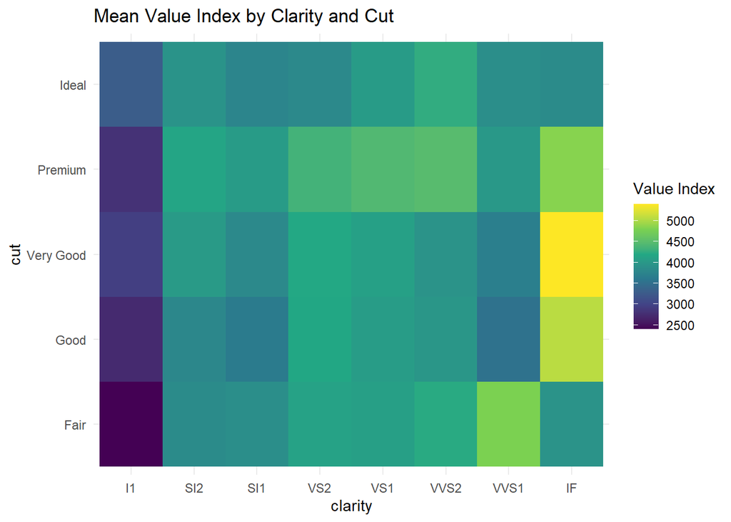

```r
mean_value_index <- diamonds %>%
  group_by(clarity, cut) %>%
  summarize(mean_value_index = mean(value_index), .groups = "drop")

ggplot(mean_value_index, aes(x = clarity, y = cut, fill = mean_value_index)) +
  geom_tile() +
  scale_fill_viridis_c() +
  labs(title = "Mean Value Index by Clarity and Cut", fill = "Value Index") +
  theme_minimal()
```

#13. Best Value Combinations

From the heatmap, here are the observations regarding clarity and cut combinations that offer the best “value” based on the color scale:

Key Observations:

2. Moderate Value (Green areas):

Combinations like Very Good cut with VS1 clarity and Premium cut with VVS1 clarity also show moderate value, suggesting that buyers can achieve a balance between quality and price.